# Overview

Dataset info

| Number of variables | 13 |
| --- | --- |
| Number of observations | 141850 |
| Total Missing (%) | 0.0% |
| Total size in memory | 15.2 MiB |
| Average record size in memory | 112.0 B |

Variables types

| Numeric | 7 |
| --- | --- |
| Categorical | 1 |
| Boolean | 0 |
| Date | 0 |
| Text (Unique) | 0 |
| Rejected | 5 |
| Unsupported | 0 |

Warnings

- `dc` has 116748 / 82.3% zeros Zeros
- `fc` has 7850 / 5.5% zeros Zeros
- `papdia` has 67654 / 47.7% zeros Zeros
- `papmoy` is highly correlated with `papdia` (ρ = 0.93413) Rejected
- `papsys` is highly correlated with `papmoy` (ρ = 0.93501) Rejected
- `pasd` has 50598 / 35.7% zeros Zeros
- `pasm` has 47992 / 33.8% zeros Zeros
- `pass` is highly correlated with `pasd` (ρ = 0.91632) Rejected
- `pnid` has 133568 / 94.2% zeros Zeros
- `pnim` is highly correlated with `pnid` (ρ = 0.95005) Rejected
- `pnis` is highly correlated with `pnim` (ρ = 0.92131) Rejected
- `time` has a high cardinality: 1441 distinct values Warning
- Dataset has 75 duplicate rows Warning

# Variables

dc  
Numeric

| Distinct count | 130 |
| --- | --- |
| Unique (%) | 0.1% |
| Missing (%) | 0.0% |
| Missing (n) | 0 |
| Infinite (%) | 0.0% |
| Infinite (n) | 0 |

| Mean | 0.79471 |
| --- | --- |
| Minimum | 0 |
| Maximum | 33 |
| Zeros (%) | 82.3% |

Toggle details

**Statistics**

Quantile statistics

| Minimum | 0 |
| --- | --- |
| 5-th percentile | 0 |
| Q1 | 0 |
| Median | 0 |
| Q3 | 0 |
| 95-th percentile | 5.3 |
| Maximum | 33 |
| Range | 33 |
| Interquartile range | 0 |

Descriptive statistics

| Standard deviation | 1.8536 |
| --- | --- |
| Coef of variation | 2.3324 |
| Kurtosis | 5.5777 |
| Mean | 0.79471 |
| MAD | 1.3082 |
| Skewness | 2.3533 |
| Sum | 112730 |
| Variance | 3.4358 |
| Memory size | 2.2 MiB |

**Histogram**

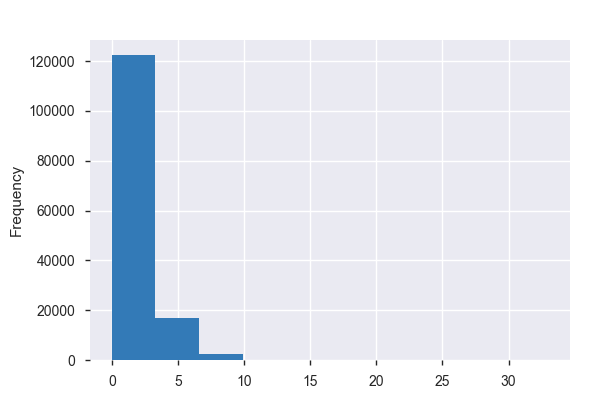

**Common Values**

| Value | Count | Frequency (%) |  |
| --- | --- | --- | --- |
| 0.0 | 116748 | 82.3% |  |
| 4.2 | 716 | 0.5% |  |
| 3.9 | 715 | 0.5% |  |
| 4.5 | 706 | 0.5% |  |
| 4.0 | 701 | 0.5% |  |
| 4.6 | 684 | 0.5% |  |
| 4.1 | 668 | 0.5% |  |
| 3.8 | 635 | 0.4% |  |
| 4.4 | 633 | 0.4% |  |
| 4.7 | 632 | 0.4% |  |
| Other values (120) | 19012 | 13.4% |  |

**Extreme Values**

Minimum 5 values

| Value | Count | Frequency (%) |  |
| --- | --- | --- | --- |
| 0.0 | 116748 | 82.3% |  |
| 1.0 | 22 | 0.0% |  |
| 1.1 | 77 | 0.1% |  |
| 1.2 | 133 | 0.1% |  |
| 1.3 | 131 | 0.1% |  |

Maximum 5 values

| Value | Count | Frequency (%) |  |
| --- | --- | --- | --- |
| 13.9 | 2 | 0.0% |  |
| 18.0 | 4 | 0.0% |  |
| 18.8 | 1 | 0.0% |  |
| 20.0 | 3 | 0.0% |  |
| 33.0 | 1 | 0.0% |  |

fc  
Numeric

| Distinct count | 260 |
| --- | --- |
| Unique (%) | 0.2% |
| Missing (%) | 0.0% |
| Missing (n) | 0 |
| Infinite (%) | 0.0% |
| Infinite (n) | 0 |

| Mean | 92.81 |
| --- | --- |
| Minimum | 0 |
| Maximum | 311 |
| Zeros (%) | 5.5% |

Toggle details

**Statistics**

Quantile statistics

| Minimum | 0 |
| --- | --- |
| 5-th percentile | 0 |
| Q1 | 80 |
| Median | 96 |
| Q3 | 110 |
| 95-th percentile | 136 |
| Maximum | 311 |
| Range | 311 |
| Interquartile range | 30 |

Descriptive statistics

| Standard deviation | 31.633 |
| --- | --- |
| Coef of variation | 0.34083 |
| Kurtosis | 2.8819 |
| Mean | 92.81 |
| MAD | 22.032 |
| Skewness | -0.90367 |
| Sum | 13165000 |
| Variance | 1000.6 |
| Memory size | 2.2 MiB |

**Histogram**

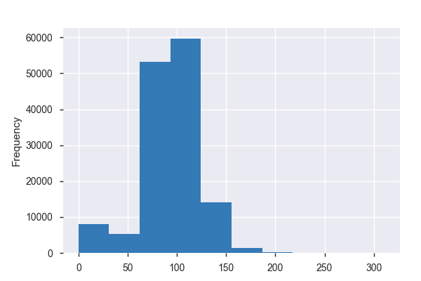

**Common Values**

| Value | Count | Frequency (%) |  |
| --- | --- | --- | --- |
| 0.0 | 7850 | 5.5% |  |
| 101.0 | 3225 | 2.3% |  |
| 100.0 | 3096 | 2.2% |  |
| 93.0 | 3040 | 2.1% |  |
| 104.0 | 3016 | 2.1% |  |
| 92.0 | 2967 | 2.1% |  |
| 97.0 | 2935 | 2.1% |  |
| 109.0 | 2917 | 2.1% |  |
| 96.0 | 2909 | 2.1% |  |
| 91.0 | 2613 | 1.8% |  |
| Other values (250) | 107282 | 75.6% |  |

**Extreme Values**

Minimum 5 values

| Value | Count | Frequency (%) |  |
| --- | --- | --- | --- |
| 0.0 | 7850 | 5.5% |  |
| 0.1 | 167 | 0.1% |  |
| 0.2 | 8 | 0.0% |  |
| 0.3 | 4 | 0.0% |  |
| 0.5 | 1 | 0.0% |  |

Maximum 5 values

| Value | Count | Frequency (%) |  |
| --- | --- | --- | --- |
| 295.0 | 2 | 0.0% |  |
| 296.0 | 1 | 0.0% |  |
| 299.0 | 1 | 0.0% |  |
| 300.0 | 2 | 0.0% |  |
| 311.0 | 1 | 0.0% |  |

id_patient  
Numeric

| Distinct count | 212 |
| --- | --- |
| Unique (%) | 0.1% |
| Missing (%) | 0.0% |
| Missing (n) | 0 |
| Infinite (%) | 0.0% |
| Infinite (n) | 0 |

| Mean | 276.76 |
| --- | --- |
| Minimum | 109 |
| Maximum | 411 |
| Zeros (%) | 0.0% |

Toggle details

**Statistics**

Quantile statistics

| Minimum | 109 |
| --- | --- |
| 5-th percentile | 158 |
| Q1 | 210 |
| Median | 268 |
| Q3 | 343 |
| 95-th percentile | 396 |
| Maximum | 411 |
| Range | 302 |
| Interquartile range | 133 |

Descriptive statistics

| Standard deviation | 77.404 |
| --- | --- |
| Coef of variation | 0.27968 |
| Kurtosis | -1.2259 |
| Mean | 276.76 |
| MAD | 68.297 |
| Skewness | 0.032984 |
| Sum | 39258069 |
| Variance | 5991.4 |
| Memory size | 2.2 MiB |

**Histogram**

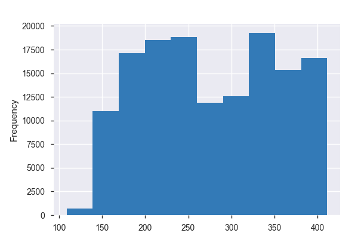

**Common Values**

| Value | Count | Frequency (%) |  |
| --- | --- | --- | --- |
| 323 | 2729 | 1.9% |  |
| 333 | 1732 | 1.2% |  |
| 275 | 1678 | 1.2% |  |
| 311 | 1427 | 1.0% |  |
| 349 | 1405 | 1.0% |  |
| 314 | 1348 | 1.0% |  |
| 233 | 1296 | 0.9% |  |
| 328 | 1281 | 0.9% |  |
| 319 | 1234 | 0.9% |  |
| 151 | 1218 | 0.9% |  |
| Other values (202) | 126502 | 89.2% |  |

**Extreme Values**

Minimum 5 values

| Value | Count | Frequency (%) |  |
| --- | --- | --- | --- |
| 109 | 702 | 0.5% |  |
| 150 | 549 | 0.4% |  |
| 151 | 1218 | 0.9% |  |
| 152 | 646 | 0.5% |  |
| 153 | 603 | 0.4% |  |

Maximum 5 values

| Value | Count | Frequency (%) |  |
| --- | --- | --- | --- |
| 407 | 644 | 0.5% |  |
| 408 | 654 | 0.5% |  |
| 409 | 551 | 0.4% |  |
| 410 | 460 | 0.3% |  |
| 411 | 464 | 0.3% |  |

papdia  
Numeric

| Distinct count | 345 |
| --- | --- |
| Unique (%) | 0.2% |
| Missing (%) | 0.0% |
| Missing (n) | 0 |
| Infinite (%) | 0.0% |
| Infinite (n) | 0 |

| Mean | 12.272 |
| --- | --- |
| Minimum | -318.36 |
| Maximum | 327 |
| Zeros (%) | 47.7% |

Toggle details

**Statistics**

Quantile statistics

| Minimum | -318.36 |
| --- | --- |
| 5-th percentile | 0 |
| Q1 | 0 |
| Median | 5 |
| Q3 | 22 |
| 95-th percentile | 36 |
| Maximum | 327 |
| Range | 645.36 |
| Interquartile range | 22 |

Descriptive statistics

| Standard deviation | 18.005 |
| --- | --- |
| Coef of variation | 1.4672 |
| Kurtosis | 70.039 |
| Mean | 12.272 |
| MAD | 12.652 |
| Skewness | 4.4912 |
| Sum | 1740800 |
| Variance | 324.2 |
| Memory size | 2.2 MiB |

**Histogram**

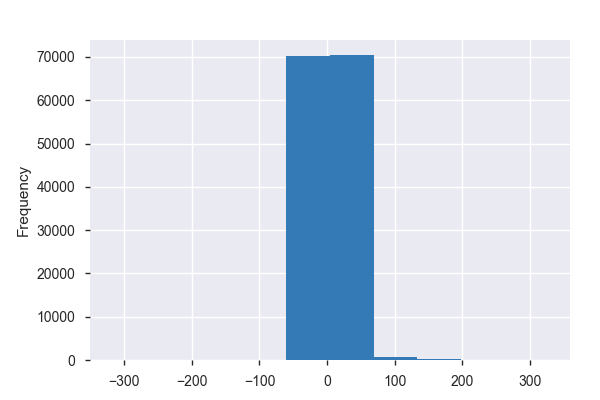

**Common Values**

| Value | Count | Frequency (%) |  |
| --- | --- | --- | --- |
| 0.0 | 67654 | 47.7% |  |
| 17.0 | 3107 | 2.2% |  |
| 18.0 | 3081 | 2.2% |  |
| 19.0 | 3032 | 2.1% |  |
| 21.0 | 2940 | 2.1% |  |
| 25.0 | 2915 | 2.1% |  |
| 23.0 | 2872 | 2.0% |  |
| 22.0 | 2841 | 2.0% |  |
| 24.0 | 2833 | 2.0% |  |
| 26.0 | 2821 | 2.0% |  |
| Other values (335) | 47754 | 33.7% |  |

**Extreme Values**

Minimum 5 values

| Value | Count | Frequency (%) |  |
| --- | --- | --- | --- |
| -318.36 | 4 | 0.0% |  |
| -317.36 | 2 | 0.0% |  |
| -316.36 | 2 | 0.0% |  |
| -315.36 | 2 | 0.0% |  |
| -314.36 | 1 | 0.0% |  |

Maximum 5 values

| Value | Count | Frequency (%) |  |
| --- | --- | --- | --- |
| 321.0 | 2 | 0.0% |  |
| 323.0 | 1 | 0.0% |  |
| 324.0 | 10 | 0.0% |  |
| 325.0 | 4 | 0.0% |  |
| 327.0 | 1 | 0.0% |  |

papmoy  
Highly correlated

*This variable is highly correlated with `papdia` and should be ignored for analysis*

| Correlation | 0.93413 |
| --- | --- |

papsys  
Highly correlated

*This variable is highly correlated with `papmoy` and should be ignored for analysis*

| Correlation | 0.93501 |
| --- | --- |

pasd  
Numeric

| Distinct count | 334 |
| --- | --- |
| Unique (%) | 0.2% |
| Missing (%) | 0.0% |
| Missing (n) | 0 |
| Infinite (%) | 0.0% |
| Infinite (n) | 0 |

| Mean | 45.84 |
| --- | --- |
| Minimum | -318.36 |
| Maximum | 323 |
| Zeros (%) | 35.7% |

Toggle details

**Statistics**

Quantile statistics

| Minimum | -318.36 |
| --- | --- |
| 5-th percentile | 0 |
| Q1 | 0 |
| Median | 59 |
| Q3 | 75 |
| 95-th percentile | 96 |
| Maximum | 323 |
| Range | 641.36 |
| Interquartile range | 75 |

Descriptive statistics

| Standard deviation | 37.844 |
| --- | --- |
| Coef of variation | 0.82556 |
| Kurtosis | 0.080182 |
| Mean | 45.84 |
| MAD | 33.957 |
| Skewness | -0.0023178 |
| Sum | 6502400 |
| Variance | 1432.1 |
| Memory size | 2.2 MiB |

**Histogram**

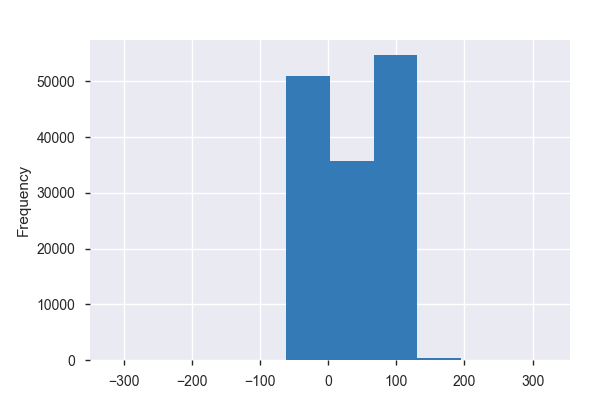

**Common Values**

| Value | Count | Frequency (%) |  |
| --- | --- | --- | --- |
| 0.0 | 50598 | 35.7% |  |
| 67.0 | 2405 | 1.7% |  |
| 70.0 | 2386 | 1.7% |  |
| 66.0 | 2373 | 1.7% |  |
| 73.0 | 2359 | 1.7% |  |
| 71.0 | 2343 | 1.7% |  |
| 64.0 | 2339 | 1.6% |  |
| 68.0 | 2307 | 1.6% |  |
| 74.0 | 2302 | 1.6% |  |
| 65.0 | 2301 | 1.6% |  |
| Other values (324) | 70137 | 49.4% |  |

**Extreme Values**

Minimum 5 values

| Value | Count | Frequency (%) |  |
| --- | --- | --- | --- |
| -318.36 | 1 | 0.0% |  |
| -315.36 | 1 | 0.0% |  |
| -314.36 | 1 | 0.0% |  |
| -313.36 | 1 | 0.0% |  |
| -311.36 | 1 | 0.0% |  |

Maximum 5 values

| Value | Count | Frequency (%) |  |
| --- | --- | --- | --- |
| 315.0 | 2 | 0.0% |  |
| 317.0 | 1 | 0.0% |  |
| 318.0 | 1 | 0.0% |  |
| 320.0 | 1 | 0.0% |  |
| 323.0 | 1 | 0.0% |  |

pasm  
Numeric

| Distinct count | 388 |
| --- | --- |
| Unique (%) | 0.3% |
| Missing (%) | 0.0% |
| Missing (n) | 0 |
| Infinite (%) | 0.0% |
| Infinite (n) | 0 |

| Mean | 57.483 |
| --- | --- |
| Minimum | -319.36 |
| Maximum | 327 |
| Zeros (%) | 33.8% |

Toggle details

**Statistics**

Quantile statistics

| Minimum | -319.36 |
| --- | --- |
| 5-th percentile | 0 |
| Q1 | 0 |
| Median | 73 |
| Q3 | 90 |
| 95-th percentile | 115 |
| Maximum | 327 |
| Range | 646.36 |
| Interquartile range | 90 |

Descriptive statistics

| Standard deviation | 46.408 |
| --- | --- |
| Coef of variation | 0.80733 |
| Kurtosis | 1.1587 |
| Mean | 57.483 |
| MAD | 40.033 |
| Skewness | 0.10417 |
| Sum | 8154000 |
| Variance | 2153.7 |
| Memory size | 2.2 MiB |

**Histogram**

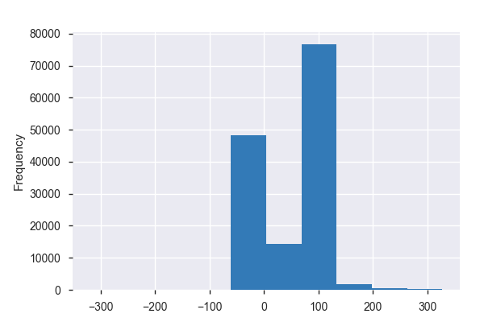

**Common Values**

| Value | Count | Frequency (%) |  |
| --- | --- | --- | --- |
| 0.0 | 47992 | 33.8% |  |
| 81.0 | 2312 | 1.6% |  |
| 80.0 | 2261 | 1.6% |  |
| 79.0 | 2233 | 1.6% |  |
| 78.0 | 2225 | 1.6% |  |
| 82.0 | 2220 | 1.6% |  |
| 77.0 | 2212 | 1.6% |  |
| 84.0 | 2180 | 1.5% |  |
| 85.0 | 2180 | 1.5% |  |
| 83.0 | 2155 | 1.5% |  |
| Other values (378) | 73880 | 52.1% |  |

**Extreme Values**

Minimum 5 values

| Value | Count | Frequency (%) |  |
| --- | --- | --- | --- |
| -319.36 | 3 | 0.0% |  |
| -318.36 | 2 | 0.0% |  |
| -318.3599853515625 | 1 | 0.0% |  |
| -317.36 | 1 | 0.0% |  |
| -316.36 | 2 | 0.0% |  |

Maximum 5 values

| Value | Count | Frequency (%) |  |
| --- | --- | --- | --- |
| 322.0 | 5 | 0.0% |  |
| 323.0 | 7 | 0.0% |  |
| 324.0 | 6 | 0.0% |  |
| 326.0 | 2 | 0.0% |  |
| 327.0 | 1 | 0.0% |  |

pass  
Highly correlated

*This variable is highly correlated with `pasd` and should be ignored for analysis*

| Correlation | 0.91632 |
| --- | --- |

pnid  
Numeric

| Distinct count | 131 |
| --- | --- |
| Unique (%) | 0.1% |
| Missing (%) | 0.0% |
| Missing (n) | 0 |
| Infinite (%) | 0.0% |
| Infinite (n) | 0 |

| Mean | 3.3418 |
| --- | --- |
| Minimum | 0 |
| Maximum | 153 |
| Zeros (%) | 94.2% |

Toggle details

**Statistics**

Quantile statistics

| Minimum | 0 |
| --- | --- |
| 5-th percentile | 0 |
| Q1 | 0 |
| Median | 0 |
| Q3 | 0 |
| 95-th percentile | 22 |
| Maximum | 153 |
| Range | 153 |
| Interquartile range | 0 |

Descriptive statistics

| Standard deviation | 14.685 |
| --- | --- |
| Coef of variation | 4.3943 |
| Kurtosis | 20.508 |
| Mean | 3.3418 |
| MAD | 6.2954 |
| Skewness | 4.581 |
| Sum | 474040 |
| Variance | 215.65 |
| Memory size | 2.2 MiB |

**Histogram**

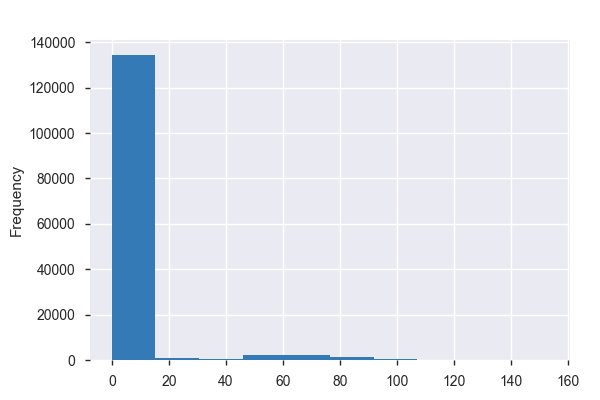

**Common Values**

| Value | Count | Frequency (%) |  |
| --- | --- | --- | --- |
| 0.0 | 133568 | 94.2% |  |
| 59.0 | 211 | 0.1% |  |
| 57.0 | 196 | 0.1% |  |
| 22.0 | 189 | 0.1% |  |
| 58.0 | 188 | 0.1% |  |
| 14.0 | 183 | 0.1% |  |
| 55.0 | 182 | 0.1% |  |
| 72.0 | 175 | 0.1% |  |
| 56.0 | 173 | 0.1% |  |
| 52.0 | 172 | 0.1% |  |
| Other values (121) | 6613 | 4.7% |  |

**Extreme Values**

Minimum 5 values

| Value | Count | Frequency (%) |  |
| --- | --- | --- | --- |
| 0.0 | 133568 | 94.2% |  |
| 1.0 | 57 | 0.0% |  |
| 2.0 | 9 | 0.0% |  |
| 3.0 | 2 | 0.0% |  |
| 4.0 | 4 | 0.0% |  |

Maximum 5 values

| Value | Count | Frequency (%) |  |
| --- | --- | --- | --- |
| 127.0 | 1 | 0.0% |  |
| 128.0 | 1 | 0.0% |  |
| 131.0 | 1 | 0.0% |  |
| 133.0 | 1 | 0.0% |  |
| 153.0 | 1 | 0.0% |  |

pnim  
Highly correlated

*This variable is highly correlated with `pnid` and should be ignored for analysis*

| Correlation | 0.95005 |
| --- | --- |

pnis  
Highly correlated

*This variable is highly correlated with `pnim` and should be ignored for analysis*

| Correlation | 0.92131 |
| --- | --- |

time  
Categorical

| Distinct count | 1441 |
| --- | --- |
| Unique (%) | 1.0% |
| Missing (%) | 0.0% |
| Missing (n) | 0 |

| 13:30 | 160 |
| --- | --- |
| 13:14 | 159 |
| 13:28 | 159 |
| Other values (1438) | 141372 |

Toggle details

| Value | Count | Frequency (%) |  |
| --- | --- | --- | --- |
| 13:30 | 160 | 0.1% |  |
| 13:14 | 159 | 0.1% |  |
| 13:28 | 159 | 0.1% |  |
| 13:31 | 159 | 0.1% |  |
| 13:29 | 159 | 0.1% |  |
| 13:11 | 158 | 0.1% |  |
| 13:27 | 158 | 0.1% |  |
| 13:32 | 158 | 0.1% |  |
| 13:13 | 158 | 0.1% |  |
| 13:05 | 158 | 0.1% |  |
| Other values (1431) | 140264 | 98.9% |  |

# Correlations

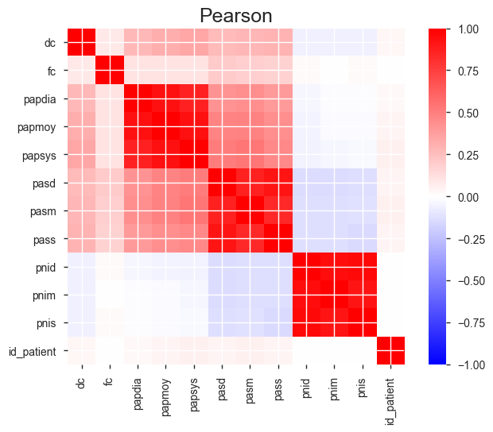

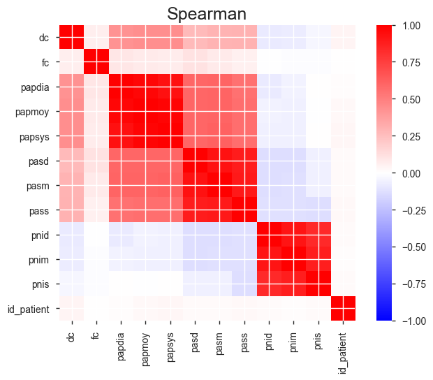

# Sample

|  | dc | fc | papdia | papmoy | papsys | pasd | pasm | pass | pnid | pnim | pnis | id_patient | time |
| --- | --- | --- | --- | --- | --- | --- | --- | --- | --- | --- | --- | --- | --- |
| 0 | 0.0 | 0.0 | 0.0 | 0.0 | 0.0 | 0.0 | 0.0 | 0.0 | 85.0 | 110.0 | 152.0 | 381 | 5:11 |
| 1 | 0.0 | 0.0 | 0.0 | 0.0 | 0.0 | 0.0 | 0.0 | 0.0 | 0.0 | 0.0 | 0.0 | 381 | 5:13 |
| 2 | 0.0 | 107.0 | 0.0 | 0.0 | 0.0 | 0.0 | 0.0 | 0.0 | 0.0 | 0.0 | 0.0 | 381 | 5:14 |
| 3 | 0.0 | 116.0 | 0.0 | 0.0 | 0.0 | 0.0 | 0.0 | 0.0 | 89.0 | 110.0 | 145.0 | 381 | 5:15 |
| 4 | 0.0 | 113.0 | 0.0 | 0.0 | 0.0 | 0.0 | 0.0 | 0.0 | 0.0 | 0.0 | 0.0 | 381 | 5:16 |